# econ-h3

Gabriel De La Rosa

5/10/2020

```r
# First, read in the data...

raw_data <- read_csv(here("Homework 3 Data (1).csv")) %>%
  clean_names()
```

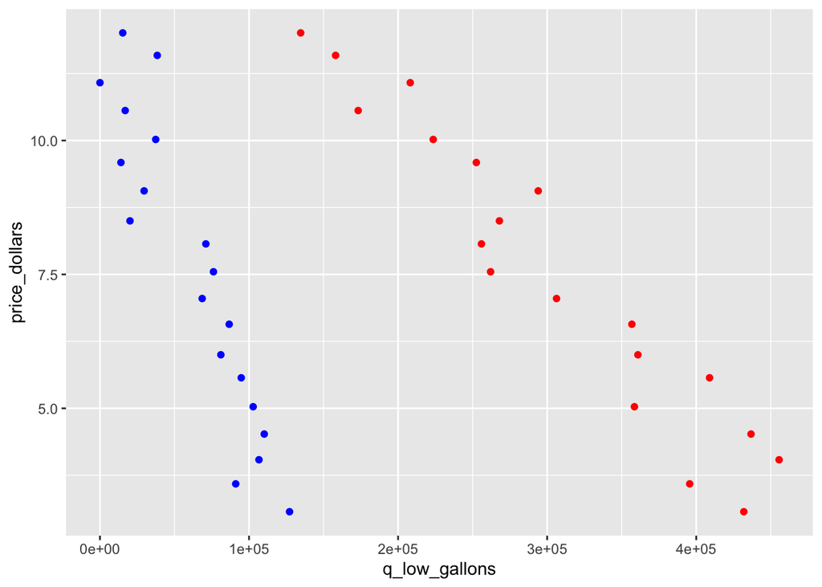

```r
# And let's take a look at this

ggplot(data = raw_data, aes(y = price_dollars)) +
  geom_point(aes(x = q_low_gallons),
             color = "blue") +
  geom_point(aes(x = q_high_gallons),
             color = "red")
```

### Question 1:

- What is the aggregate daily demand curve for gasoline?
- What is the supply curve for gasoline?
- What is the “benefit” to consumers under the status quo?
- What is the “benefit” to producers under the status quo?
- What is the environmental cost under the status quo (locally and in the rest of the world)?

##### Make linear models for low and high

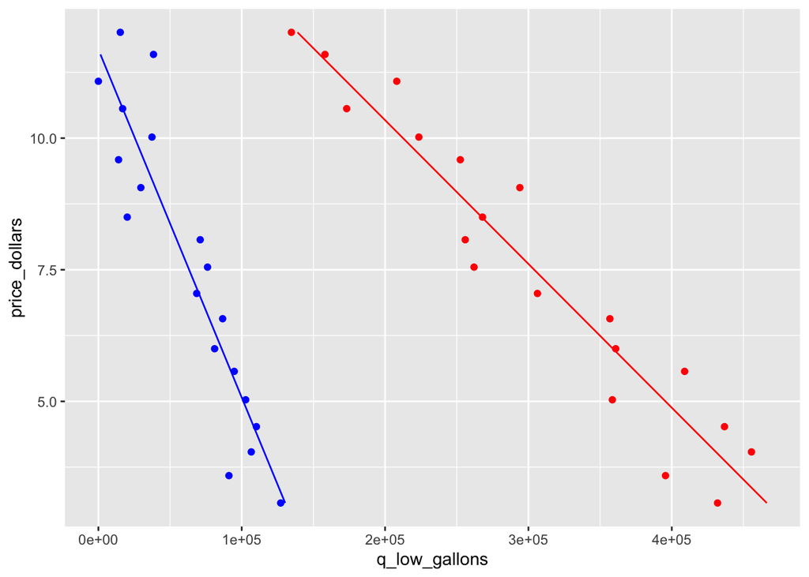

```r
# First, let's pull linear models for both of these:

lm_high <- lm(price_dollars~q_high_gallons, data = raw_data)

# Extract the coefficients as numbers...
lm_high_coef <- coef(lm_high)[2]
lm_high_int <- coef(lm_high)[1]

# Then make a function
high_price_fx <- function(gallons){
  price = lm_high_coef * gallons + lm_high_int
  return(price)
}
high_gal_fx <- function(price){
  gallons = (price - lm_high_int) / lm_high_coef
  gallons[gallons<0] <- NA
  return(gallons)
}

# Repeat for low...
lm_low <- lm(price_dollars ~ q_low_gallons, data = raw_data)
lm_low_coef <- coef(lm_low)[2]
lm_low_int <- coef(lm_low)[1]
low_price_fx <- function(gallons){
  price = lm_low_coef * gallons + lm_low_int
  return(price)
}
low_gal_fx <- function(price){
  gallons = (price - lm_low_int) / lm_low_coef
  gallons[gallons < 0] <- NA
  return(gallons)
}

# Test these funcitons on the initial df...

lm_predict <- raw_data %>%
  mutate(low_predict = low_gal_fx(price_dollars)) %>%
  mutate(high_predict = high_gal_fx(price_dollars))

# Plot them to make sure...
ggplot(data = lm_predict, aes(y = price_dollars)) +
  geom_point(aes(x = q_low_gallons),
             color = "blue") +
  geom_point(aes(x = q_high_gallons),
             color = "red") +
  geom_line(aes(x = low_predict),
             color = "blue") +
  geom_line(aes(x = high_predict),
            color = "red")
```

```r
# YEW
```

##### Create an aggregate demand curve:

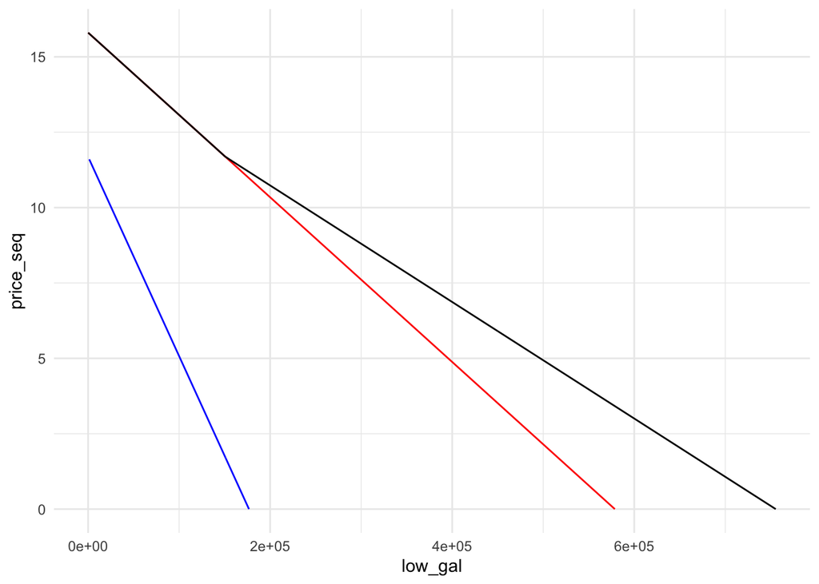

```r
# make a range of prices to predict these...
price_seq <- seq(0, lm_high_int, by = .1)

# Then add demand curve predicted values, then add them.
agg_demand <- data.frame(price_seq) %>%
  mutate(low_gal = low_gal_fx(price_seq)) %>%
  mutate(high_gal = high_gal_fx(price_seq)) %>%
  rowwise() %>%
  mutate(agg = sum(low_gal, high_gal, na.rm = TRUE))

# Nice plot
ggplot(data = agg_demand, aes(y = price_seq)) +
  geom_line(aes(x = low_gal),
            color = "blue") +
  geom_line(aes(x = high_gal),
            color = "red") +
    geom_line(aes(x = agg),
            color = "black") +
  theme_minimal()
```

##### Let’s make an LM for the aggregate demand curve, when it doesn’t equal the high curve…:

```r
# This is for just high...
agg_demand_low <- agg_demand %>%
  filter(!is.na(low_gal))
# Make LM
agg_lm <- lm(price_seq~agg, data = agg_demand_low)
# Pull coefficients
agg_coef <- coef(agg_lm)[2]
agg_int <- coef(agg_lm)[1]
# Make functions
agg_price_fx <- function(gallons){
  price = agg_coef * gallons + agg_int
  return(price)
}
agg_gal_fx <- function(price){
  gallons = (price - agg_int) / agg_coef
  gallons[gallons < 0] <- NA
  return(gallons)
}
```

##### Agg demand curve is…

$$price = \left\{\begin{matrix} -2.73*10^{-5} (gallons)+ 15.8, & gallons < 150789.3 \\ -1.93*10^{-5}(gallons) + 14.6, & gallons \geq 150789.3 \end{matrix}\right.$$

##### Supply Curve for Gasoline

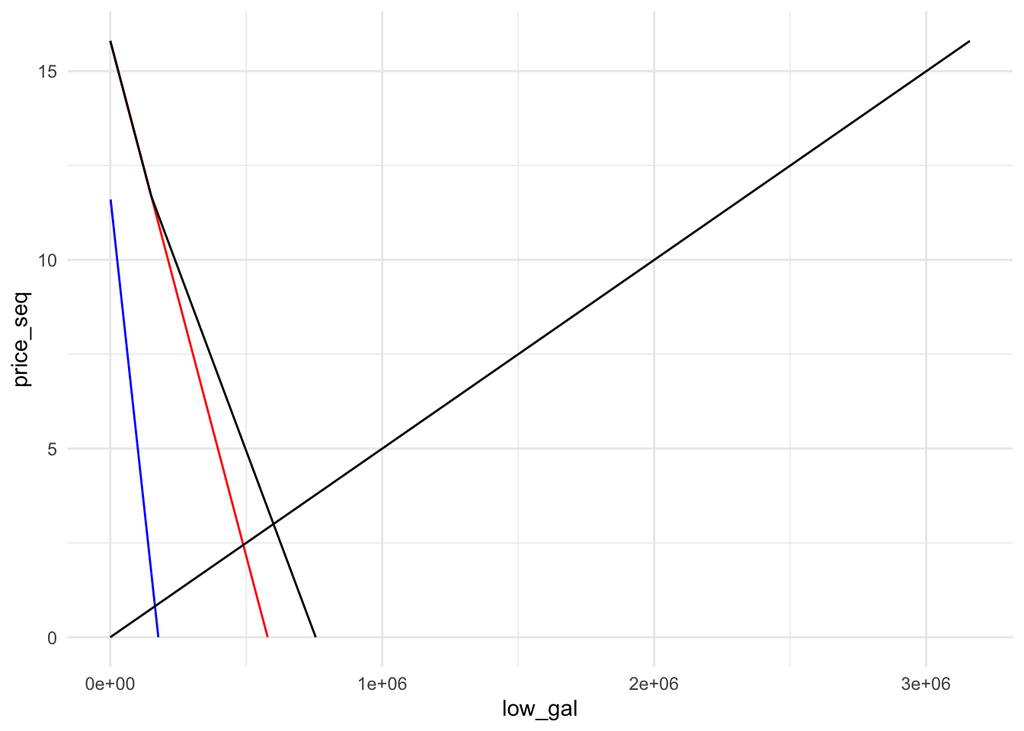

```r
# Supply curve: current gas price is 3
# intercept = 0,0
current_gallons <- agg_gal_fx(3)
supply_coef <- (3/current_gallons)
supply_price_fx <- function(gallons){
  price = supply_coef*gallons
  price[price<0] <- NA
  return(price)
}
supply_gal_fx <- function(price){
  gallons <- price/supply_coef
  gallons[gallons<0] <- NA
  return(gallons)
}

# Test this and add to other df...

sup_dem <-agg_demand %>%
  mutate(supply_gal = supply_gal_fx(price_seq))

# Plot it to double check...
ggplot(data = sup_dem, aes(y = price_seq)) +
  geom_line(aes(x = low_gal),
            color = "blue") +
  geom_line(aes(x = high_gal),
            color = "red") +
    geom_line(aes(x = agg),
            color = "black") +
  geom_line(aes(x = supply_gal)) +
  theme_minimal()
```

##### Supply curve

price = 5.0 * 10<sup>-6</sup> * gallons

##### Benefit to consumers:

The benefit to consumers is the triangle above the equilibrium, so …

```r
# The slope changes at price = lm_high_intercept, this is the kink point
kink_gal <- agg_gal_fx(lm_low_int)
# get your x intercept...
agg_x_int <- agg_gal_fx(0)
# This is the number of gallons consumed at $3
agg_eq_gal <- agg_gal_fx(3)
# Integrate under both curves...
cons_surp1 <- integrate(high_price_fx, 0, kink_gal)$value
cons_surp2 <- integrate(agg_price_fx, kink_gal, agg_x_int)$value
# Add em together
added_surp <- cons_surp1 + cons_surp2
# Then subtract the square under this (price = 3, demand = agg_eq_gal)
cons_surp <- added_surp - (3 * agg_eq_gal)
```

The consumer benefit is…3.804673210^{6}

##### Producer Surplus

Producer surplus is below the equilibrium…so…

```r
# First, calculate net cost to producers
prod_cost <- integrate(supply_price_fx, 0, agg_eq_gal)$value
# Then, subtract from the square for equilibrium point:
prod_surplus <- (3*agg_eq_gal) - prod_cost
```

the producer surplus is…9.003022710^{5}

##### Environmental Cost

The environmental cost is $1.50 per gallon, within the country.

```r
# Cost is the number of gallons produced times the cost per gallon
env_cost_sq <- agg_eq_gal * 1.50
env_world_cost_sq <- agg_eq_gal * 0.5
```

The environmental cost to the country is…9.003022710^{5}

The environmental cost to the world is…3.001007610^{5}

### Question 2

- How is consumer benefit divided between “High” and “Low” income consumers?

Let’s find out the number of gallons each income bracket consumes at equilibrium:

```r
# High eq gallons:
high_gal_sq <- high_gal_fx(3)
low_gal_sq <- low_gal_fx(3)
# Then integrate under their curves:
high_int_sq <- integrate(high_price_fx, 0, high_gal_sq)$value
low_int_sq <- integrate(low_price_fx, 0, low_gal_sq)$value
# Then, subtract the square for equilibrium points:
high_surplus_sq <- high_int_sq - (3*high_gal_sq)
low_surplus_sq <- low_int_sq - (3*low_gal_sq)
# Then, get what percent each bracket makes of the total surplus:
high_surplus_pct <- high_surplus_sq / (high_surplus_sq +low_surplus_sq)
low_surplus_pct <- low_surplus_sq / (high_surplus_sq +low_surplus_sq)
```

High income consumers receive 0.8402756 of the benefit, while low income consumers receive 0.1597244 of the benefit.

### Question 3:

A gas tax of $1.00/gal. is proposed. What would be the effects of this tax on:

1. The amount of gasoline produced and consumed.
2. The price of gasoline.
3. Welfare of “High” income consumers.
4. Welfare of “Low” income consumers. Welfare of gas producers.
5. Local environmental damage.
6. Rest of world environmental damage. Total revenue generated by the tax.

##### a. Gas produced and consumed:

We can add one (y-int) to our supply function.

```r
# Let's make a pair of functions for this...
tax_supply_price_fx <- function(gallons){
  price = supply_coef*gallons + 1
  price[price<0] <- NA
  return(price)
}
tax_supply_gal_fx <- function(price){
  gallons <- price/supply_coef + 1
  gallons[gallons<0] <- NA
  return(gallons)
}
```

Then, we can solve for the intercept… Using algebra…

price = supply_coef*gallons + 1 price = agg_coef* gallons + agg_int

supply_coef * gallons + 1 = agg_coeff * gallons + agg_int

supply_coef * gallons - agg_coeff * gallons = agg_int - 1 gallons(supply_coef - agg_coeff) = agg_int - 1 gallons = (agg_int - 1)/(supply_coef - agg_coef)

```r
tax_gal <- (agg_int - 1)/(supply_coef - agg_coef)
```

There are 5.590909410^{5} gallons produced with the tax.

#### b. Tax price

We can plug our new equilibrium gallons into the new supply curve:

```r
tax_price <- tax_supply_price_fx(tax_gal)
```

The new cost of gas is 3.7945161

```r
# Let's graph this to make sure...

# tax_dem <- sup_dem %>%
#   mutate(new_supply = tax_supply_gal_fx(price_seq))
#
# ggplot(data = tax_dem, aes(y = price_seq)) +
#   geom_line(aes(x = low_gal),
#             color = "blue") +
#   geom_line(aes(x = high_gal),
#             color = "red") +
#     geom_line(aes(x = agg),
#             color = "black") +
#   #geom_line(aes(x = supply_gal)) +
#   geom_line(aes(x = new_supply),
#             linetype = "dotted") +
#   theme_minimal()
```

##### c. Welfare of high income consumers:

First, let’s find out how much high income consumers actually consume under the new price:

```r
# Plug the tax price into our gallon function:
high_gal_tax <- high_gal_fx(tax_price)
# Integrate under the curve:
high_int_tax <- integrate(high_price_fx, 0, high_gal_tax)$value
# Then, subtract the profit square: tax_price = total price with tax
high_tax_ben <- high_int_tax - (high_gal_tax * tax_price)
```

The net benefit to high income groups is 2.640385410^{6}

##### d. Welfare of low income consumers:

```r
# Plug the tax price into our gallon function:
low_gal_tax <- low_gal_fx(tax_price)
# Integrate under the curve:
low_int_tax <- integrate(low_price_fx, 0, high_gal_tax)$value
# Then, subtract the profit square:
low_tax_ben <- low_int_tax - (low_gal_tax * tax_price)
```

The net benefit to low income groups is -1.706582610^{6}

##### e. Local environmental damage:

The local environmental damage is 1.50 x the new amount of gasoline produced

```r
tax_env_damage <- 1.50 * tax_gal
```

The local environmental damage is 8.38636410^{5}

##### f. Global environmental damage:

The global environmental damage is 0.50 x the new amount of gasoline produced

```r
tax_world_damage <- 0.50 * tax_gal
```

The global environmental damage is 2.795454710^{5}

##### g. Tax revenue generated

The tax revenue generated is the tax price * gallons produced

```r
tax_rev <- tax_gal * 1.00
```

The tax revenue generated is $5.590909410^{5}

### Question 4.

Now, assume that all revenue from a tax will be redistributed to the two groups in proportion to their pre-tax consumption of gas. For example, if 80% of the gas was consumed by High income consumers, then they get 80% of the tax revenue.

Also assume that “Low” income consumers bear all local environmental costs. For a range of gas taxes (ranging from $0 - $5.00/gal), calculate the effects of the tax on:

1. Overall welfare of “High” income consumers
2. Overall welfare of “Low” income consumers
3. Gas producers

##### First, we need to find equilibrium gallons and prices for 1:5 dollars…

```r
# Gallons (per equation in 3a):
tax_gal2 <- (agg_int - 2)/(supply_coef - agg_coef)
tax_gal3 <- (agg_int - 3)/(supply_coef - agg_coef)
tax_gal4 <- (agg_int - 4)/(supply_coef - agg_coef)
tax_gal5 <- (agg_int - 5)/(supply_coef - agg_coef)

tax_supply_price2_fx <- function(gallons){
  price = supply_coef*gallons + 2
  price[price<0] <- NA
  return(price)
}
tax_supply_price3_fx <- function(gallons){
  price = supply_coef*gallons + 3
  price[price<0] <- NA
  return(price)
}
tax_supply_price4_fx <- function(gallons){
  price = supply_coef*gallons + 4
  price[price<0] <- NA
  return(price)
}
tax_supply_price5_fx <- function(gallons){
  price = supply_coef*gallons + 5
  price[price<0] <- NA
  return(price)
}

# Prices # This is the total price at the new production (gallons) for each tax:
tax_price1 <- tax_supply_price_fx(tax_gal)
tax_price2 <- tax_supply_price2_fx(tax_gal2)
tax_price3 <- tax_supply_price3_fx(tax_gal3)
tax_price4 <- tax_supply_price4_fx(tax_gal4)
tax_price5 <- tax_supply_price5_fx(tax_gal5)

# This is the cost of the tax * the number of gallons produced
tax_rev <- tax_gal * 1.00
tax_rev2 <- tax_gal2 * 2.00
tax_rev3 <- tax_gal3 * 3.00
tax_rev4 <- tax_gal4 * 4.00
tax_rev5 <- tax_gal5 * 5.00
# Porportional gas consumption:
# This is the amount they consume at price 0 divided by the aggregate gallons consumed
high_prop <- high_gal_fx(3)/agg_eq_gal
low_prop <- low_gal_fx(3)/agg_eq_gal
```

##### Overall welfare of “high” income consumers

We can calculate welfare like we did above, however, we need to add in the porportional tax return to high income consumers…

```r
# Plug the tax price into our gallon function:
high_gal_tax <- high_gal_fx(tax_price)
high_gal_tax2 <- high_gal_fx(tax_price2)
high_gal_tax3 <- high_gal_fx(tax_price3)
high_gal_tax4 <- high_gal_fx(tax_price4)
high_gal_tax5 <- high_gal_fx(tax_price5)
# Integrate under the curve:
high_int_tax <- integrate(high_price_fx, 0, high_gal_tax)$value
high_int_tax2 <- integrate(high_price_fx, 0, high_gal_tax2)$value
high_int_tax3 <- integrate(high_price_fx, 0, high_gal_tax3)$value
high_int_tax4 <- integrate(high_price_fx, 0, high_gal_tax4)$value
high_int_tax5 <- integrate(high_price_fx, 0, high_gal_tax5)$value
# Then, subtract the profit square, and add back in the porportional tax revenue:
high_tax_new_ben <- high_int_tax - (high_gal_tax * tax_price) + tax_rev * high_prop
high_tax_new_ben2 <- high_int_tax2 - (high_gal_tax2 * tax_price2) + tax_rev2 * high_prop
high_tax_new_ben3 <- high_int_tax3 - (high_gal_tax3 * tax_price3) + tax_rev3 * high_prop
high_tax_new_ben4 <- high_int_tax4 - (high_gal_tax4 * tax_price4) + tax_rev4 * high_prop
high_tax_new_ben5 <- high_int_tax5 - (high_gal_tax5 * tax_price5) + tax_rev5 * high_prop
```

##### Overall welfare for low income consumers:

```r
# Plug the tax price into our gallon function:
low_gal_tax <- low_gal_fx(tax_price)
low_gal_tax2 <- low_gal_fx(tax_price2)
low_gal_tax3 <- low_gal_fx(tax_price3)
low_gal_tax4 <- low_gal_fx(tax_price4)
low_gal_tax5 <- low_gal_fx(tax_price5)
# Integrate under the curve:
low_int_tax <- integrate(low_price_fx, 0, low_gal_tax)$value
low_int_tax2 <- integrate(low_price_fx, 0, low_gal_tax2)$value
low_int_tax3 <- integrate(low_price_fx, 0, low_gal_tax3)$value
low_int_tax4 <- integrate(low_price_fx, 0, low_gal_tax4)$value
low_int_tax5 <- integrate(low_price_fx, 0, low_gal_tax5)$value
# Then, subtract the profit square, and add back in the porportional tax revenue:
# For low income, we also need to subtract the environmental damage from this:
# Benefit = The integral - Tax cost + proportional tax revenue - environmental damage
low_tax_new_ben <- low_int_tax + (tax_rev * low_prop) - (low_gal_tax * tax_price)  - (1.50 * tax_gal)
low_tax_new_ben2 <- low_int_tax2 - (low_gal_tax2 * tax_price2) + (tax_rev2 * low_prop) - (1.50 * tax_gal2)
low_tax_new_ben3 <- low_int_tax3 - (low_gal_tax3 * tax_price3) + (tax_rev3 * low_prop) - (1.50 * tax_gal3)
low_tax_new_ben4 <- low_int_tax4 - (low_gal_tax4 * tax_price4) + (tax_rev4 * low_prop) - (1.50 * tax_gal4)
low_tax_new_ben5 <-low_int_tax5 - (low_gal_tax5 * tax_price5) + (tax_rev5 * low_prop) - (1.50 * tax_gal5)
```

##### Overall welfare for gas producers:

We need calculate total revenue at each price Then subtract the cost to producers

```r
# First, calculate net cost to producers
prod_cost_tax1 <- integrate(supply_price_fx, 0, tax_price)$value
prod_cost_tax2 <- integrate(supply_price_fx, 0, tax_price2)$value
prod_cost_tax3 <- integrate(supply_price_fx, 0, tax_price3)$value
prod_cost_tax4 <- integrate(supply_price_fx, 0, tax_price4)$value
prod_cost_tax5 <- integrate(supply_price_fx, 0, tax_price5)$value

# Then, subtract from the square for equilibrium point:
prod_surplus_tax1 <- (supply_gal_fx(tax_price)*tax_price) - prod_cost_tax1
prod_surplus_tax2 <- (supply_gal_fx(tax_price2)*tax_price2) - prod_cost_tax2
prod_surplus_tax3 <- (supply_gal_fx(tax_price3)*tax_price3) - prod_cost_tax3
prod_surplus_tax4 <- (supply_gal_fx(tax_price4)*tax_price4) - prod_cost_tax4
prod_surplus_tax5 <- (supply_gal_fx(tax_price5)*tax_price5) - prod_cost_tax5
```

```r
tax <- c(1,2,3,4,5)
high_benefit <- c(high_tax_new_ben, high_tax_new_ben2, high_tax_new_ben3, high_tax_new_ben4, high_tax_new_ben5)
low_benefit <- c(low_tax_new_ben, low_tax_new_ben2, low_tax_new_ben3, low_tax_new_ben4, low_tax_new_ben5)
prod_surplus <- c(prod_surplus_tax1, prod_surplus_tax2, prod_surplus_tax3, prod_surplus_tax4, prod_surplus_tax5)

tax_benefit_df <- data.frame(tax, high_benefit, low_benefit, prod_surplus)
```

### Question 5:

A new electric car technology is invented and it lowers the demand curves of all income groups by half (vertically). Under these new demand curves, what are the effects on:

1. Gas consumption by “High” income consumers
2. Gas consumption by “Low” income consumers
3. Gas price
4. Local environmental damage from gasoline
5. Rest of world environmental damage from gasoline

##### a. Gas consumption on high income:

First, let’s make new demand curves:

```r
# The new demand curves are just the old curves with the intercept halved:
# For high
electric_high_price_fx <- function(gallons){
  price = (lm_high_coef) * gallons + (lm_high_int/2)
  return(price)
}
electric_high_gal_fx <- function(price){
  gallons = (price - lm_high_int/2) / lm_high_coef
  gallons[gallons<0] <- NA
  return(gallons)
}
# And for low income...

electric_low_price_fx <- function(gallons){
  price = (lm_low_coef/2) * gallons + (lm_low_int/2)
  return(price)
}
electric_low_gal_fx <- function(price){
  gallons = (price - (lm_low_int/2)) / lm_low_coef
  gallons[gallons < 0] <- NA
  return(gallons)
}
```

##### Aggregate demand:

```r
# This is just the original aggregate demand curve with the intercept halved:
electric_agg_gal_fx <- function(price){
  gallons = (price - (agg_int/2)) / agg_coef
  gallons[gallons < 0] <- NA
  return(gallons)
}

electric_agg_price_fx <- function(gallons){
  price = agg_coef * gallons + (agg_int/2)
  return(price)
}
```

Then, we need to find out total consumption and the equilibrium price:

```r
# The new equilibrium gallons are where the equations meet...
elec_gallons <-  (agg_int/2)/(supply_coef - agg_coef)
# The total gallons consumed is this plugged into the new agg demand curve:
elec_agg_price <- electric_agg_price_fx(elec_gallons)
```

Then, we can plug this price back into the new demand curves:

```r
elec_high_gal <- electric_high_gal_fx(elec_agg_price)
```

So,high income groups consume 2.344154710^{5} gallons

##### b.

We repeat for low income groups…

```r
elec_low_gal <- electric_low_gal_fx(elec_agg_price)
```

Finding low income groups consume 6.568529110^{4} of gasoline

##### c.

Gas price is 1.5 as calculated above…

##### d.

The local environmental damage is 1.5 * new equilibrium gallons consumed:

```r
elec_env_damage <- (1.5 * elec_gallons)
```

##### e.

The global environmental damage is 0.5 * new equilibrium gallons…

```r
elec_world_damage <- (0.5 * elec_gallons)
```

which is 1.500503810^{5} dollars.

### Question 6:

The goal is to find the tax that causes consumption of the same amount of gas as with electric technology.

so…we can plug the electric quantity into the original aggregate demand curve…

```r
opt_price <- agg_price_fx(elec_gallons)
```

So, we want gas to cost 8.7998426 dollars after tax.

Which is just the new price minus $3.

```r
opt_tax <- (opt_price - 3)
```

And so the optimal tax is 5.7998426